# Point Process Models with Gaussian Process ‘random effects’

## Alternative title: Everyone is going nuts for GPs, so why not us

### Andy Seaton

### September 2018

# Introduction to Point Processes

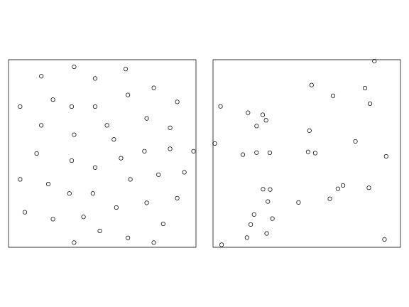

# Poisson Point Process

The intensity function `\(\lambda(s)\)` is the heart of point process models.

Here is one realisation:

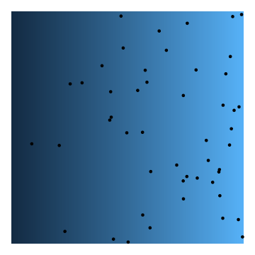

# Poisson Point Process

The intensity function `\(\lambda(s)\)` is the heart of point process models.

And another:

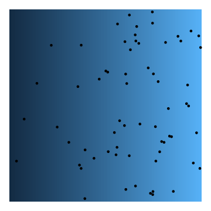

# Poisson Point Process

The intensity function `\(\lambda(s)\)` is the heart of point process models.

And another another:

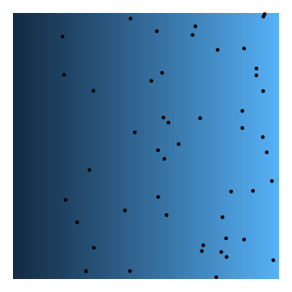

# Poisson Point Process

- The intensity `\(\lambda(s)\)` determines where points are more/less likely to occur

- The **expected** number of points in a region `\(B\)` is `\(\Lambda_B = \int_B \lambda(s) ds\)`

- The number of points is a random variable `\(N(B) \sim Pois(\Lambda_B)\)`

# Poisson Point Process

- KEY ASSUMPTION:   disjoint regions are independent, conditional on `\(\lambda(s)\)`

[figure not shown]

# Poisson Point Process

- KEY ASSUMPTION:   disjoint regions are independent, conditional on `\(\lambda(s)\)`

[figure not shown]

- So your model for `\(\lambda(s)\)` better be really good

- We usually model `\(\log \lambda(s) = \text{Intercept} + \text{Spatial Covariates}\)`

# Poisson Point Process

A not so good `\(\lambda(s)\)` model:

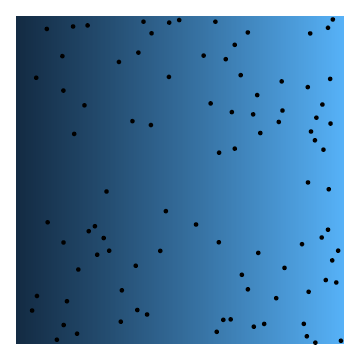

# Poisson Point Process

The true intensity looks like this

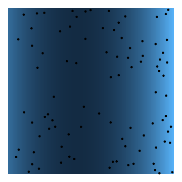

- but we don't know this, all we have are some covariates that get us some of the picture

# Poisson Point Process

What are the consequences of having a bad model for `\(\lambda(s)\)`?

- Still some dependence in the observations, breaks model assumptions and can lead to **"spurious significance"**

- Model will extrapolate poorly to new areas or time periods

What can I do?

- If you have good reason to suspect a covariate you are missing will be useful, try to collect it (easier said than done...)

- Could be a dependence that no covariate could ever capture (e.g. sociality, seed dispersal limitation)

- If no covariate - consider spatially structured random effect (Gaussian Process in the this talk)

# Introduction to Gaussian Processes

We want something in our model that tries to fill the place of a missing covariate

(not quite, e.g. sociality, but not a bad way to think at first)

- Gaussian Processes define probability distributions for **functions**

- In our case, the function will act like a spatial covariate `\(f(s)\)`

- We write `\(f \sim \mathcal{GP}(\mu, \kappa)\)`

- `\(\mu\)` is a mean function

- `\(\kappa\)` is a covariance function (more on this later)

# Introduction to Gaussian Processes

Some realisations of 1D Gaussian Process:

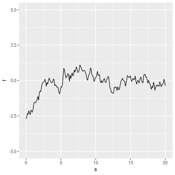

# Introduction to Gaussian Processes

Some realisations of 1D Gaussian Process:

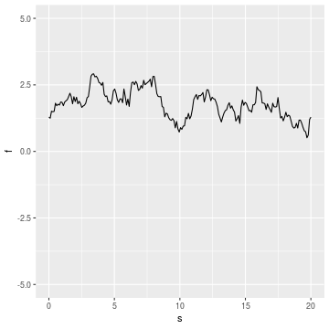

# Introduction to Gaussian Processes

Some realisations of 1D Gaussian Process:

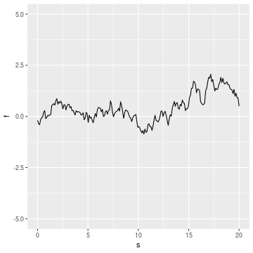

# Introduction to Gaussian Processes

Some realisations of 1D Gaussian Process:

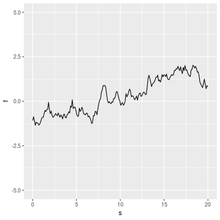

# Introduction to Gaussian Processes

The covariance function controls the ruggedness

Previous slides had `\(f \sim \mathcal{GP}(\mu = 0, \kappa = \text{exponential model})\)`

`\(\kappa(s_1, s_2) = \exp(-r(s_1, s_2))\)`

where `\(r(s_1,s_2)\)` is distance between `\(s_1\)` and `\(s_2\)`

We can include a parameter to control the **correlation range**

# Introduction to Gaussian Processes

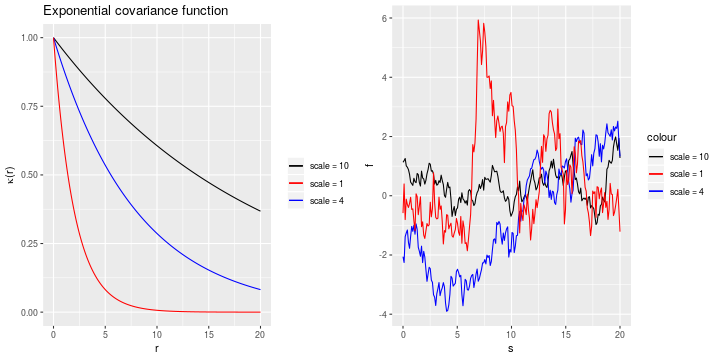

- Can make realisations smoother by using Matern covariance model

- Exponential model is special case of Matern (not very smooth case)

# 2D Matern Examples

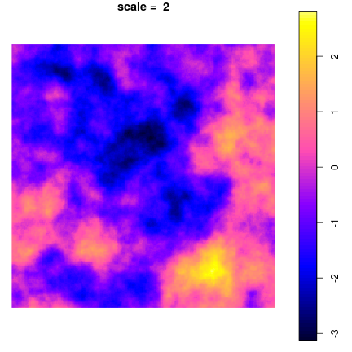

# 2D Matern Examples

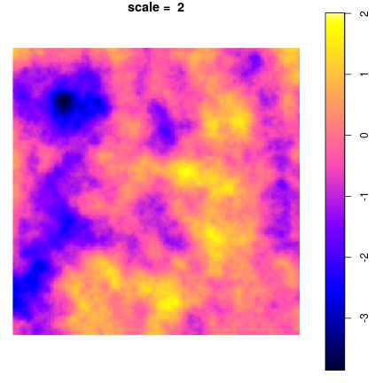

# 2D Matern Examples

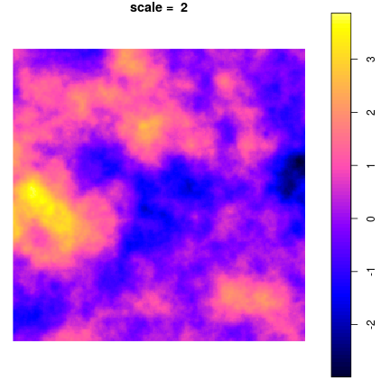

# 2D Matern Examples

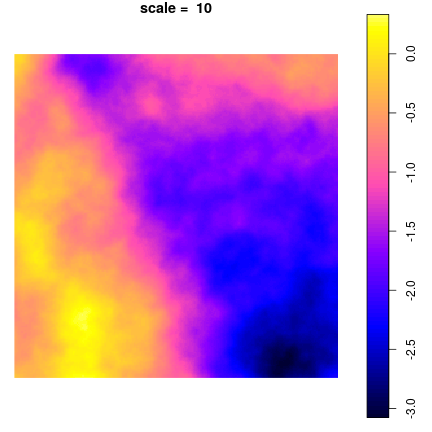

# 2D Matern Examples

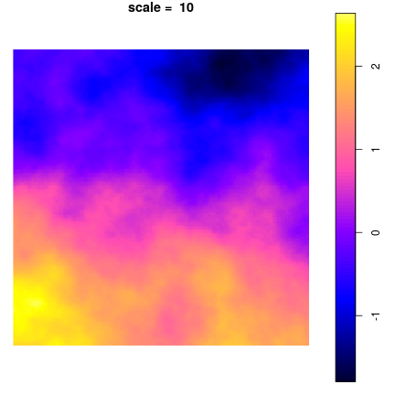

# 2D Matern Examples

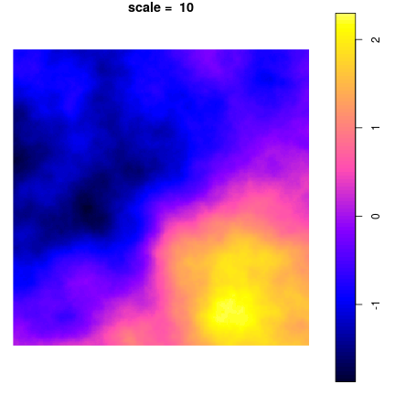

# Putting it all together

$$
`\begin{aligned}
\log \lambda(s) &= \text{Intercept} + \text{Spatial Covariates} \\[20pt]
\mathbb{E}(N(B)) &= \Lambda_B = \int_B \lambda(s) ds \qquad \text{(Not a random variable}) \\[20pt]
N(B) &\sim Pois(\Lambda_B)
\end{aligned}`
$$

# Putting it all together

$$
`\begin{aligned}
\log \lambda(s) &= \text{Intercept} + \text{Spatial Covariates} + \mathcal{GP}(\mu = 0, \text{Matern}) \\[20pt]
\mathbb{E}(N(B)) &= \Lambda_B = \int_B \lambda(s) ds \qquad \text{(IS a random variable}) \\[20pt]
N(B) &\sim Pois(\Lambda_B)
\end{aligned}`
$$

Now the Poisson rate parameter is allowed to be random.

c.f.  Negative-binomial distribution

# An example

Can fit these models using `inlabru`   (see inlabru.org for 5-day workshop materials)

[figure not shown]

# An example

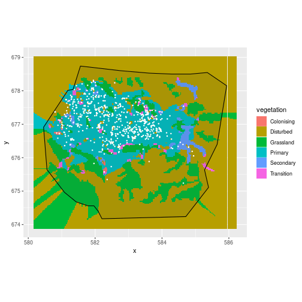

# An example

[figure not shown]

# Do I need my Gaussian Process?

- Model evaluation is an active area of research

- DIC one way to compare models

- Better way, sample from posterior and calculate summary statistics for each sample

- Calculate summary statistics for your observations, see how they fit with posterior samples.

- Keep an eye on this space